# Estimate Robustness of Real Networks

## Plot results

Here we set some plotting parameters for consistency across panels.

```r
axis_text_size <- 10
axis_title_size <- 14
```

In order to plot the analytical model, we create a dataframe object of a sequence of fragility values spanning out observed range and the corresponding predicted robustness ($\hat{R}$).

```r
new_f <- seq(from = 0, to = 2.5, length.out = 100)

# the estimated Robusteness (Rhat)
est_r <- exp(-new_f - new_f^2) #predictRobustness(new_f)

fit_df <- data.frame(new_f = new_f,
                     est_r = est_r)
```

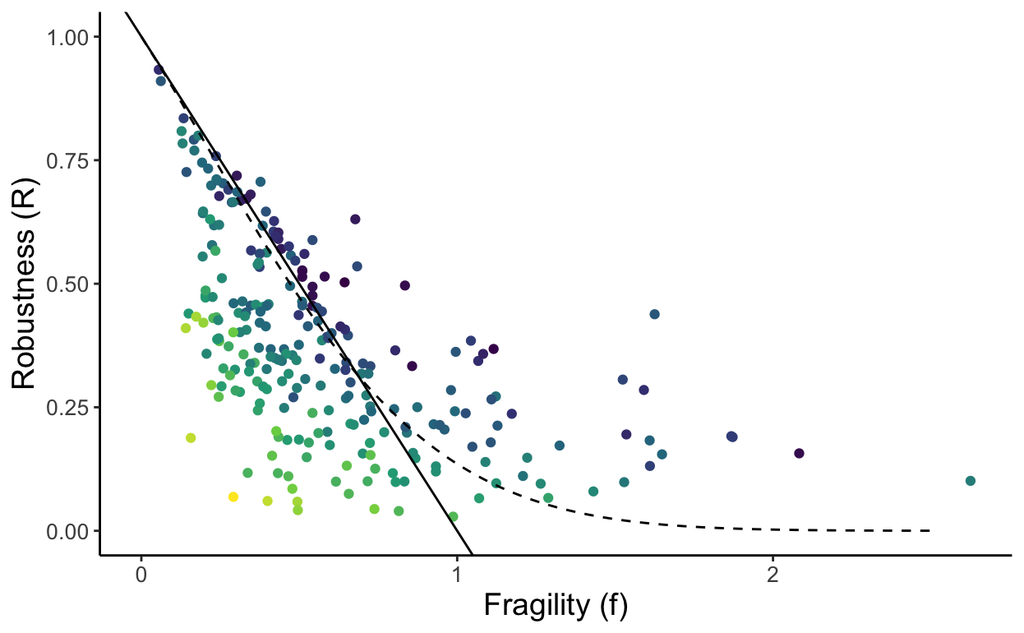

```r
g1 <- ggplot(df_webs, aes(x = fragility,
                     y = robustness,
                     color = log10(dispersion))) +
  geom_point() +
  # scale_color_viridis_c(guide =
  #                         guide_legend(override.aes = list(color = "white"))) +
    scale_color_viridis_c(guide = FALSE) +
  geom_abline(slope = -1, intercept = 1) +
  geom_line(data = fit_df, mapping = aes(x = new_f, y = est_r, color = NULL),
            linetype = 2) +
  ylab("Robustness (R)") +
  xlab("Fragility (f)") +
   labs(color = expression(log[10](d))) +
  theme_classic() +
  theme(axis.text = element_text(size = axis_text_size),
        axis.title = element_text(size = axis_title_size)) +
  theme(
        legend.text = element_text(color = "white"),
        legend.title = element_text(color = "white")
        )


print(g1)
#
ggsave(g1,filename = "robust-fragility-empirical.png",
       width = 20, height = 12, units = "cm",
       scale = 1)
```

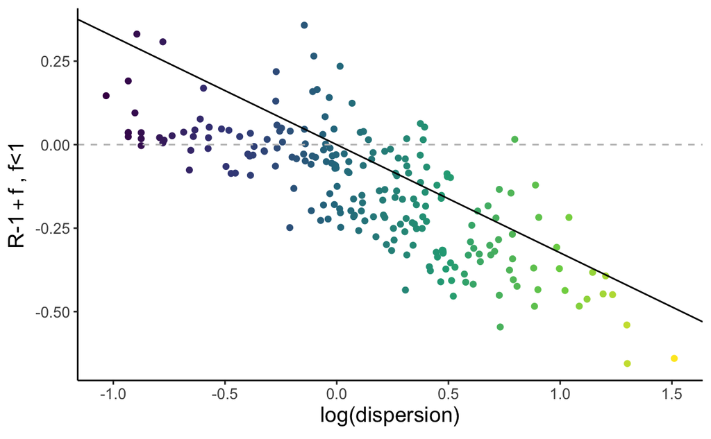

```r
df_webs <- df_webs %>% mutate(residRf = robustness -1 + fragility)

# model of the residuals of R = 1-f tor f<1 on log(dispersion)
mRf <- lm( residRf ~ -1 + log10(dispersion) , data = df_webs %>% filter(fragility < 1))



g3_simplified <- ggplot(df_webs %>% filter(fragility < 1),
                        aes(x = log10(dispersion),
                            y = residRf,
                            color = log10(dispersion))) +
  geom_point() +
  scale_color_viridis_c(guide = FALSE) +
  geom_hline(yintercept = 0, color = "grey", linetype = 2) +
  # geom_smooth(method = lm) +
  geom_abline(slope = coef(mRf),
              intercept = 0) +
  labs(color = expression(log(d)),
       shape = "Web Type") +
  ylab(TeX("$R -1 + f$ , $f<1$")) +
  xlab(TeX("$\\log(\\dispersion)$")) +
  theme_classic() +
  theme(axis.text = element_text(size = axis_text_size),
        axis.title = element_text(size = axis_title_size))


print(g3_simplified)

ggsave(g3_simplified,filename = "resid-dispersion.png",
       width = 20, height = 12, units = "cm")
```

```r
# g_ab <- (g1 | g3_simplified)
#
# print(g_ab)
#
# ggsave(filename = "frag-robust-disp.png", plot = g_ab,
       # width = 15, height = 9, units = "cm")
```

We can then use a linear model as fit to Figure S2.1b to account for dispersion for a new metric that describes Robustness ($R$) given Fragility ($f$) and Dispersion ($d$) of a given network.

## Calculate modified measure of fragility $f^*$

```r
# regress robsustness against (1 - fragility) and then esimate the coefficient
# of the linear regression of the residuals to this plot against
# log10(dispersion) and calculate
# fstar = fragility + lambda * log10(dispersion)
df_webs <- df_webs %>%
  mutate(fstar = fragility - coef(mRf) *
           log10(dispersion))
```

write the dataframe to file for sharing

```r
# and write to file
write_csv(df_webs, path = "web_statistics.csv")
```

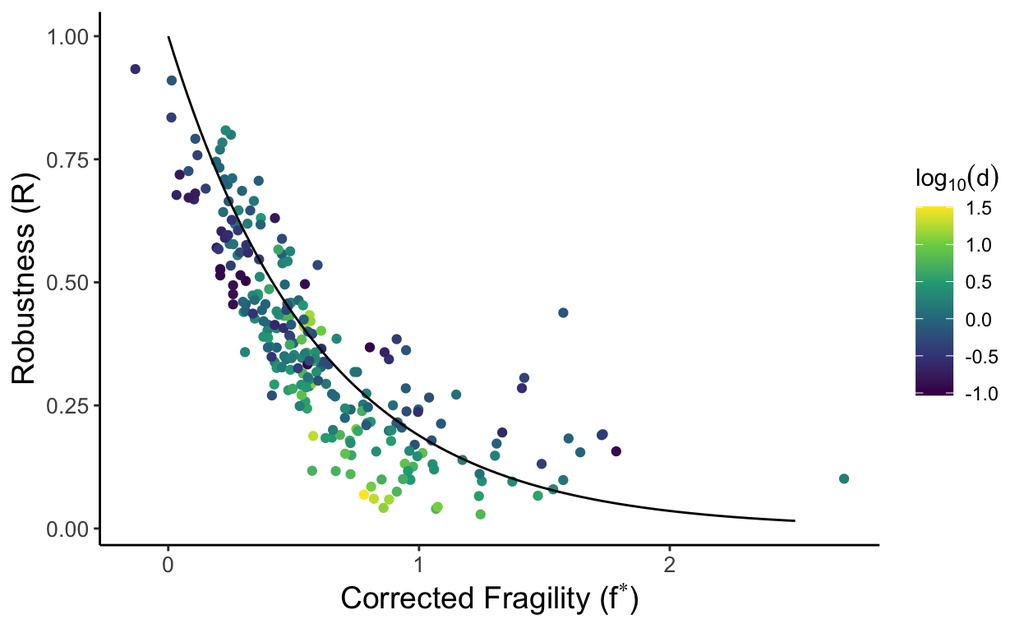

```r
g6 <- ggplot(df_webs, aes(x = fstar,
                          y = robustness,
                          color = log10(dispersion))) +
  geom_point() +
  scale_color_viridis_c() +
  geom_line(data = fit_df, mapping = aes(x = new_f, y = exp(-5/3*new_f), color = NULL)) +
  ylab("Robustness (R)") +
  xlab(TeX("Corrected Fragility $(f^*)$")) +
   labs(color = expression(log[10](d))) +
  theme_classic() +
  theme(axis.text = element_text(size = axis_text_size),
        axis.title = element_text(size = axis_title_size))

print(g6)

ggsave(g6, filename = "R-by-fstar.png",
       width = 20, height = 12, units = "cm")
```

```r
NA
NA
```

The correlation coefficients for Robustness (R) with the various estimates are:

- $\text{cor}(R,f)$ = -0.64
- $\text{cor}(R,log(d))$ = -0.47
- $\text{cor}(R,f^*)$ = -0.88